# act_report

## Report: act_report

## 1 - Introduction

The goal of this project is to provide a student a hands-on example of how to gather, clean and analyse real data. ["WeRateDogs"](https://twitter.com/dog_rates) Twitter account with over 4 million followers that rates people's dogs with a humorous comment about the dog was selected as data source.

Project "Wrangling and Analyse Data" consist of following steps:

- data gathering,
- data assessment,
- data cleaning,
- data storing,
- last but not least, data analysis and visualisation.

Let me walk you through them in more details below.

## 2 - Data wrangling

Data gathering process was split in 3 different sub-tasks: first, read 'twitter-archive-enhanced' file to Data Frame; second, read tweet image predictions tsv file by using request library; and third, collect additional tweet data using Twitter API. Due to technical issues with obtaining developer twitter account, I leveraged 'tweet-json.txt' file that containes additional data available through Twitter APIs and and read json file line by line to a Data Frame.

After saving each data Data Frame separately, I conducted visual and programmatic assessment to define tidiness ad quality issues. During visual assessment I was randomly viewing subsets of data frames and during programmatic assessment I was mainly using such methods as 'describe', 'info', 'sample' and etc.

Data assessment resulted in a list of quality and tidiness issues (16 in total, documented details can be found in 'wrangle_act.ipynb' file), that were tackled and resolved during cleaning process. Cleaned data was saved as 'twitter_archive_master.csv' file as per requirements and going forward was used for further analysis and visualisation.

## 3 - Data analysis and visualisation

After analysing cleaned data we can make share several insights:

- According to processed data, tweets that has **"pupper" dog stage have lower rating** and lower retweet count on average compare to other dog stages. Max number of retweets falls on "doggo", closely followed by tweets with "pupper".
- Top 5 **most popular dog names** within tweets are Charlie, Oliver, Cooper, Lucy, Penny.
- Most **popular dog breed** in tweets is Golden Retriever, nevertheless Labrador Retrievres average rating is slightly higher compare to Golden Retriever.

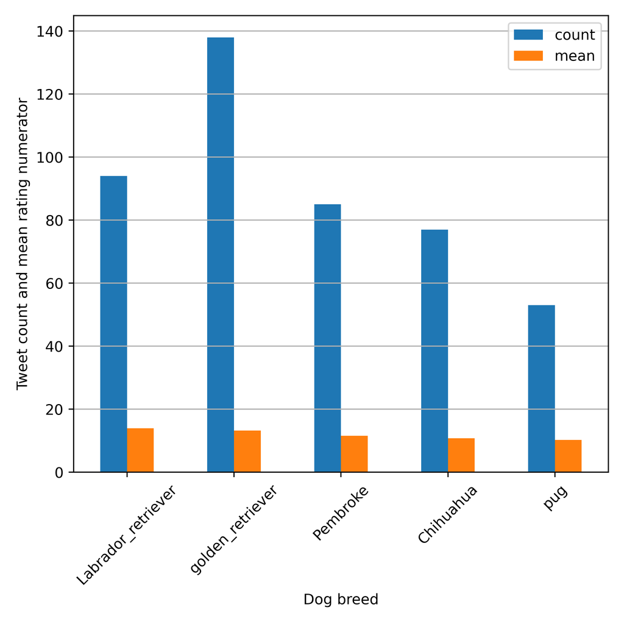

- After analysing sesonality of tweets data showed that **original tweets** are mostly posted on Monday-Wednesday and users are less active over weekend. Despite people are most activly posting on Mondays, Twitter users mostly **retweeting** tweets that are posted on Wednesdays.

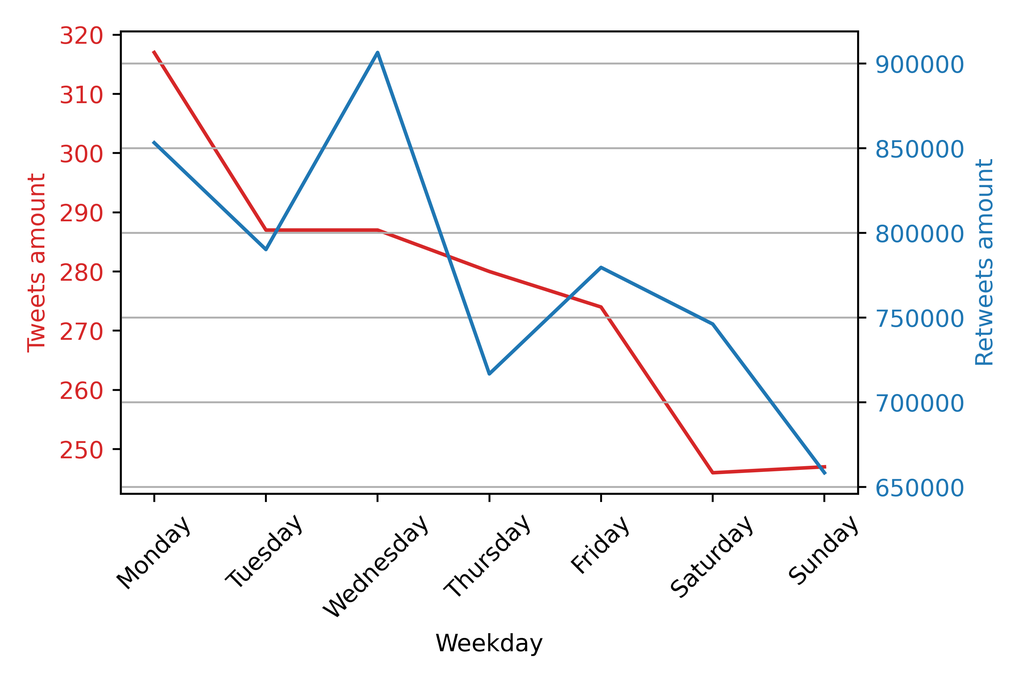

## 4 - Conclusion

Twitter data contains vast range of interesting insights, so we encourage others to play Sherlock and try to find even more enlightments and clues!

[figure not shown]